# Chapter 02: Rutherford

August 22, 2014

## Data Entry (Excel)

Data can be entered into Excel, saved as a CSV file, and then imported into RStudio.

## Data Entry (R)

Data can also be entered directly into R using the `data.frame()` function.

```r
wordRecall = data.frame(
  words.30  = c(7, 3, 6, 6, 5, 8, 6, 7),
  words.60  = c(7, 11, 9, 11, 10, 10, 11, 11),
  words.180 = c(8, 14, 10, 11, 12, 10, 11, 12)
  )

wordRecall
```

```
##   words.30 words.60 words.180
## 1        7        7         8
## 2        3       11        14
## 3        6        9        10
## 4        6       11        11
## 5        5       10        12
## 6        8       10        10
## 7        6       11        11
## 8        7       11        12
```

- The `Subjects` columns are omitted
- Variable (object) names in R cannot start with a number; `30s`, `60s` and `180s` are illegal

## Tidy Data

- What are "tidy" data?
- Why are our data not "tidy"?
- How would the `wordRecall` data look if it were "tidy"?

## Our Data

Cause of messiness (Wickham, 2012) is that the column headers are values, not variable names

[output not shown]

## Wide vs. Long Formatted Data

For experimental data, such as the word recall data, in the **wide** format of the data,

- Each column is a different level of the experiment.
- Each row may contain several cases (subjects)

In the **long** (tidy) format of the data,

- Each row represents a different case (in this example a subject)
- There is *only one* variable that denotes the outcome value
- There is *only one* variable that denotes the experimental condition

```
##    condition words
## 1   words.30     7
## 2   words.30     3
## 3   words.30     6
## 4   words.30     6
## 5   words.30     5
## 6   words.30     8
## 7   words.30     6
## 8   words.30     7
## 9   words.60     7
## 10  words.60    11
## 11  words.60     9
## 12  words.60    11
## 13  words.60    10
## 14  words.60    10
## 15  words.60    11
## 16  words.60    11
## 17 words.180     8
## 18 words.180    14
## 19 words.180    10
## 20 words.180    11
## 21 words.180    12
## 22 words.180    10
## 23 words.180    11
## 24 words.180    12
```

## Data Preparation: Melting Data to the Long Format

The `melt()` function from the **reshape2** package can re-format the data from wide to long (tidy). The arguements are (1) the input data, and (2) any columns which are already variables

```r
library(reshape2)
wordRecall2 = melt(wordRecall)
head(wordRecall2, 10)
```

```
##    variable value
## 1  words.30     7
## 2  words.30     3
## 3  words.30     6
## 4  words.30     6
## 5  words.30     5
## 6  words.30     8
## 7  words.30     6
## 8  words.30     7
## 9  words.60     7
## 10 words.60    11
```

## Data Preparation: Renaming Variables

We can rename the variables

```r
names(wordRecall2) = c("condition", "words")
head(wordRecall2, 10)
```

```
##    condition words
## 1   words.30     7
## 2   words.30     3
## 3   words.30     6
## 4   words.30     6
## 5   words.30     5
## 6   words.30     8
## 7   words.30     6
## 8   words.30     7
## 9   words.60     7
## 10  words.60    11
```

## The `str()` Function

```r
str(wordRecall2)
```

```
## 'data.frame':    24 obs. of  2 variables:
##  $ condition: Factor w/ 3 levels "words.30","words.60",..: 1 1 1 1 1 1 1 1 2 2 ...
##  $ words    : num  7 3 6 6 5 8 6 7 7 11 ...
```

Factors are how R treats categorical variables.

- Factors look like character vectors, but, are more than just a list of labels
- Factors have information stored about a pre-defined set of factor levels
- Not every factor level need be represented in the data
- Some functions treat factors in a special manner

## Data Preparation: Renaming Factor Levels

If we have a factor, we can get a vector of the factor levels using the `levels()` function.

```r
levels(wordRecall2$condition)
```

```
## [1] "words.30"  "words.60"  "words.180"
```

We can rename the factor levels by assigning new names using the `c()` function.

```r
levels(wordRecall2$condition) = c("30's", "60's", "90's")
levels(wordRecall2$condition)
```

```
## [1] "30's" "60's" "90's"
```

## Data Summary (Marginal Distribution)

```r
library(psych)
describe(wordRecall2$words)
```

```
##   vars  n mean   sd median trimmed  mad min max range  skew kurtosis   se
## 1    1 24    9 2.67     10     9.1 2.97   3  14    11 -0.34    -0.76 0.55
```

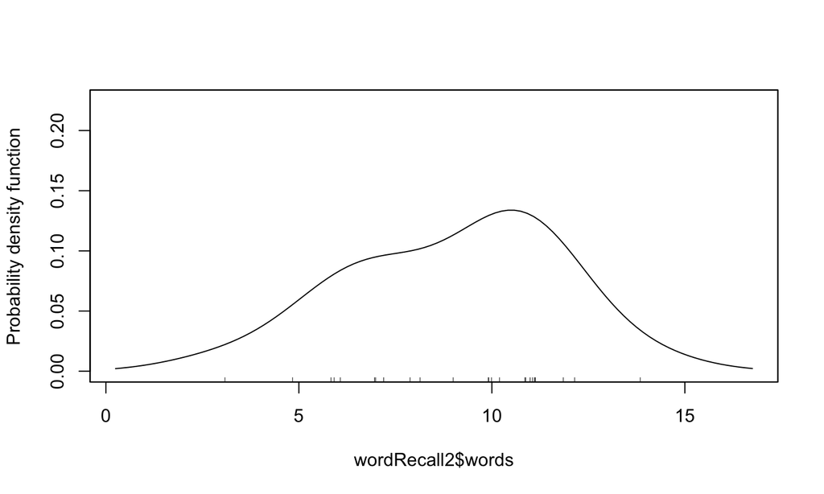

```r
library(sm)
sm.density(wordRecall2$words)
```

## Data Summary (Conditional Distribution)

```r
# Needs psych library
describeBy(wordRecall2$words, wordRecall2$condition)
```

```
## group: 30's
##   vars n mean   sd median trimmed  mad min max range  skew kurtosis   se
## 1    1 8    6 1.51      6       6 1.48   3   8     5 -0.65    -0.61 0.53
## --------------------------------------------------------
## group: 60's
##   vars n mean   sd median trimmed  mad min max range  skew kurtosis  se
## 1    1 8   10 1.41   10.5      10 0.74   7  11     4 -1.06    -0.31 0.5
## --------------------------------------------------------
## group: 90's
##   vars n mean   sd median trimmed  mad min max range skew kurtosis   se
## 1    1 8   11 1.77     11      11 1.48   8  14     6    0     -0.9 0.63
```

## Data Summary (Conditional Distribution)

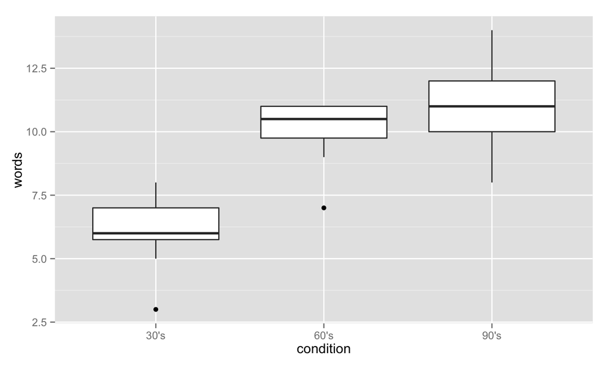

```r
library(ggplot2)
ggplot(data = wordRecall2, aes(x = condition, y = words)) +
  geom_boxplot()
```

## Scatterplots (Rutherford, p. 25)

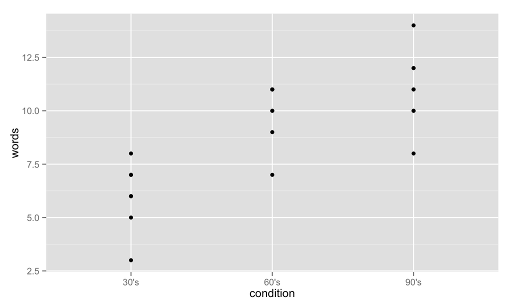

```r
library(ggplot2)
ggplot(data = wordRecall2, aes(x = condition, y = words)) +
  geom_point()
```

## Scatterplots (Rutherford, p. 25)

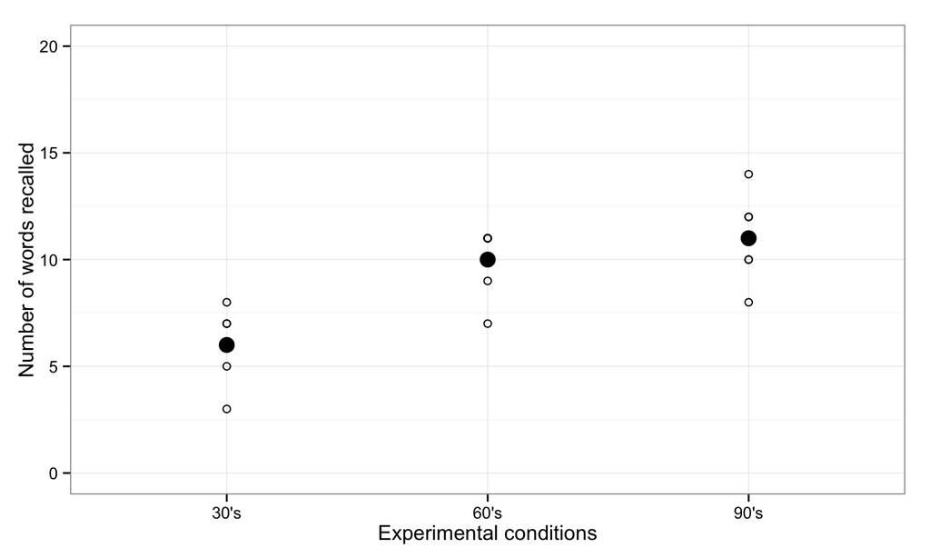

```r
ggplot(data = wordRecall2, aes(x = condition, y = words)) +
  geom_point(pch = 1) +
  stat_summary(fun.y = "mean", geom = "point", pch = 19, size = 4) +
  theme_bw() +
  scale_x_discrete(name = "Experimental conditions") +
  scale_y_continuous(name = "Number of words recalled", lim = c(0, 20))
```